# Sea ice seasonality

Here we calculate sea ice season for the southern hemisphere, after the method of Massom et al. (2013).

The northern hemisphere requires a different approach, so here we set up the files for testing but leave the application for later.

## Tools

We use the R package *raadtools* which provides access to a collection of all NSIDC 25 km sea ice concentration for both southern and northern hemispheres. Reading the ice data is provided by the *readice* function which accepts a vector of dates, other options and returns a *Raster* object.

# Preliminaries

First we pre-cache a single file of all daily data for each year after doing some sanity checks. This allows ease of code development and debugging.

```r
library(raadtools)
library(dplyr)
sfiles <- icefiles(hemisphere = "south")

sfiles %>% summarize(count = n(), datemin = min(date), datemax = max(date))
```

```
##   count    datemin    datemax
## 1 12405 1978-10-26 2017-03-29
```

# ISSUES

Data are missing from 1987-12-04 to early Jan 1988, Massom et al. use “the climatology” but it seems pertinent to just assume we cannot calculate day of retreat for that season since the mean value can be wildly different from a given year.

Data are two-daily from 1978 to mid 80s, we just interpolate to fill the days.

# Utilities.

```r
dp <- "/mnt/acebulk/seaiceseason"

## function to ensure we have clean boundaries (untidy for now)
snaptodoy <- function(date, mon = 2, mday = 15, start = TRUE) {
  ldate <- as.POSIXlt(date)
  doy <- as.integer(format(ISOdatetime(ldate$year + 1900, mon, mday, 0, 0, 0, tz = "UTC"), "%j"))
  test <- ldate$yday > doy
  if (start) {
    if (test) {ldate$mday <- mday; ldate$mon <- mon - 1; ldate$year <- ldate$year + 1}
    if (!test) {ldate$mday <- mday; ldate$mon <- mon - 1}
  } else {
    if (test) {ldate$mday <- mday; ldate$mon <- mon - 1}
    if (!test) {ldate$mday <- mday; ldate$mon <- mon + 1; ldate$year <- ldate$year - 1}

  }
  as.POSIXct(ldate)
}

## function to read a series of time slices, and interpolate a full sequence optionally

readIceBrick <- function(dates, hemisphere = "south", interpolate = TRUE) {
        x <- suppressWarnings(readice(dates, hemisphere = hemisphere,  setNA = FALSE))
        ## we need to interpolate (or insert monthly clim)
        if (!interpolate) return(x)
        if (nlayers(x) == length(dates)) return(x)

        xmat <- values(x)
        xmat[xmat > 100] <- 0
        dimnames(xmat) <- list(NULL, NULL)

        ## rebuild the entire data set with linear interpolation
        xmat2 <- matrix(0, nrow(xmat), length(dates))
        t0 <- timedateFrom(getZ(x))
        for (i in seq_len(nrow(xmat2))) {
          xmat2[i,] <- approxfun(t0, xmat[i,], rule = 2)(dates)
        }
        x <- setValues(x, xmat2)
        ##names(x) <- sprintf("layer%0.3i", seq(nlayers(x)))
        names(x) <- format(dates, "%Y_%m_%d")
        setZ(x, dates)

}


calc_ice_season <- function(yfile, threshval = 15) {
  hemi <- substr(basename(yfile[1]), 1, 5)
  threshold.value <- threshval
  ndays <- 5

  len <- 15

  ## north_ice_1979_02_15_1980_02_14.grd"
  ice <- brick(yfile)
  year_n <- nlayers(ice)
  template <- ice[[1]] * 0
  icemat <- values(ice)
  icemat[icemat > 100] <- 0

  ## here we need to get the next day for the interpolation . . .
  ##icemat[is.na(icemat)] <- 0
  adv <- numeric(nrow(icemat))
  ret <- numeric(nrow(icemat))
  threshold <- icemat >= threshold.value


  rsum <- .rowSums(threshold, nrow(threshold), ncol(threshold))
  ## all values less
  alllt <- rsum == 0
  ## all values greater than threshold
  allgt <- rsum == ncol(threshold)
  ## values missing
  ##miss <- icemat[,1] > 100
  ## all the rest
  visit <- which(!alllt & !allgt)
  for (ii in seq_along(visit)) {
    rl <- rle(threshold[visit[ii], ])

    ##    annual day of advance is the time when the ice
    ##    concentration in a given pixel first exceeds 15% (taken to
    ##    approximate the ice edge) for at least 5 days
    for (ir in seq_along(rl$lengths)) {
      if (rl$values[ir] & rl$lengths[ir] >= ndays) {
        adv[visit[ii]] <- if (ir == 1) 1L else sum(head(rl$lengths, ir - 1))
        break;
      }
    }
    if (adv[visit[ii]] == 0) adv[visit[ii]] <- NA

    ##while day of retreat
    ## ## is the time when concentration remains below 15% until the end
    ## ## of the given sea ice year
    revlengths <- rev(rl$lengths)
    revvals <- rev(rl$values)
    for (ri in seq_along(revlengths)) {
      if (revvals[ri]) {
        ret[visit[ii]] <- if (ri == 1) length(year_n) else sum(revlengths[ri:length(revlengths)])
        break;
      }
    }
    if (ret[visit[ii]] == 0) ret[visit[ii]] <- NA
  }
  adv[alllt] <- NA
  ## adv[miss] <- NA
  adv[allgt] <- 1
  ret[alllt] <- NA
  ret[allgt] <- length(year_n)

  list(adv = setValues(template, adv), ret = setValues(template, ret))

}
```

Collate a single file for each year, in a local folder. Years start at February 15 and end on February 14 in the southern hemisphere, and start August 15 and end August 14 in the northern hemisphere.

```r
hmon <- 2
hemi <- "south"
hmday <- 15
allfiles <- sfiles
startdate <- snaptodoy(min(allfiles$date), mon = hmon, mday = hmday, start = TRUE)
endate <- snaptodoy(max(allfiles$date), mon = hmon, mday = hmday -1, start = FALSE)

## start dates, including the end of the last year
bdates <- seq(startdate, endate, by = "1 year")

for (iyear in seq_along(head(bdates, - 1))) {
#yearn <- (ydates %>% filter(yearN == levels(yearN)[iyear]))$date
yearn <- seq(bdates[iyear], bdates[iyear + 1], by = "1 day")
tfilename <- file.path(dp, "yearfiles",
sprintf("%s_ice_%s_%s.grd", hemi, format(min(yearn), "%Y_%m_%d"),
format(max(yearn), "%Y_%m_%d")))
print(iyear)
if (!file.exists(tfilename)) {
ice <- readIceBrick(yearn, hemisphere = hemi, interpolate = TRUE)
writeRaster(ice, tfilename)
}
}
```

# Calculating ice season

Ice season is defined by a calculated day of *advance* and *retreat* for a pixel corresponding to the development of sea ice cover and its subsequent melting.

> The annual day of advance is the time when the ice concentration in a given pixel first exceeds 15% (taken to < approximate the ice edge) for at least 5 days while day of retreat is the time when concentration remains below 15% until the end of the given sea ice year. Massom et al (2013)

The method proceeds to threshold the ice values at 15% or greater concentration, then processing the sequence base on the rules in Massom et al. (2103). In short:

- advance is the first day at or above the threshold after which the subsequent four days are also at or above the threshold
- retreat is the day after which the threshold is not reached again.

```r
library(raadtools)
files <- list.files(file.path(dp, "yearfiles"), full.names = TRUE, pattern = "^south.*grd$")

advance <- vector("list", length(files))
retreat <- vector("list", length(files))
for (i in seq_along(files)) {
  ## obj contains 2 rasters "adv" and "ret"
  obj <- calc_ice_season(files[i])
  advance[[i]] <- obj$adv
  retreat[[i]] <- obj$ret
}


advance <- brick(stack(advance), filename = file.path(dp, "south_advance.grd"))
retreat <- brick(stack(retreat), filename = file.path(dp, "south_retreat.grd"))
```

# Exploring ice season

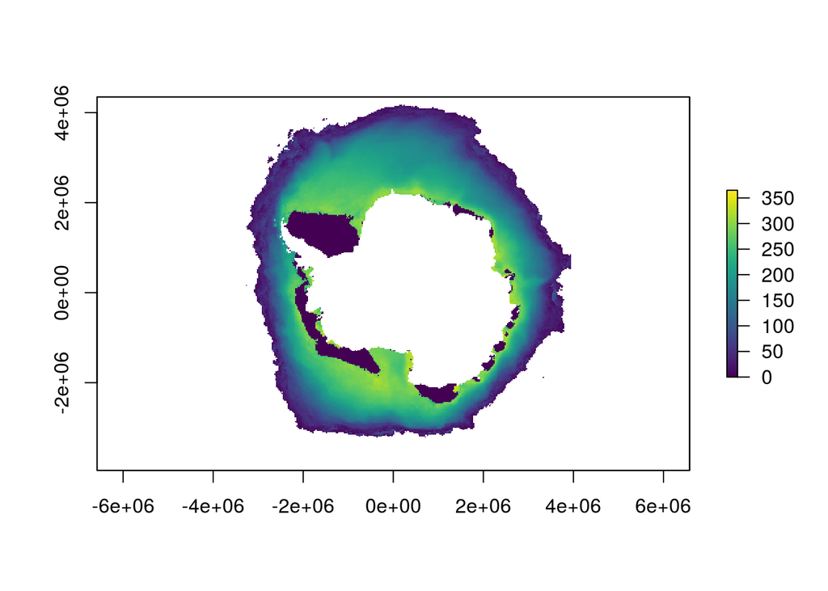

```r
advance <- brick(file.path(dp, "south_advance.grd"))
retreat <- brick(file.path(dp, "south_retreat.grd"))
isd <- calc(retreat - advance, sd, na.rm = TRUE)
msd <- calc(retreat - advance, median, na.rm = TRUE)


plot(msd, col = viridis::viridis(100), zlim = c(0, 365))
```

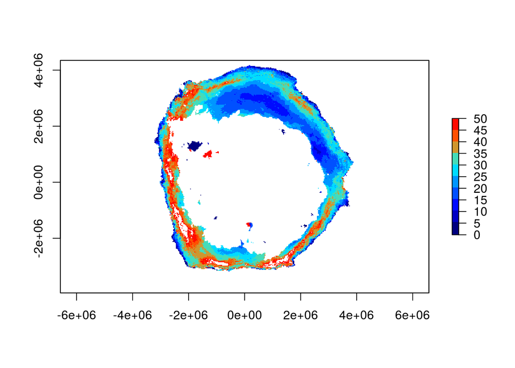

```r
jet.colors_alt <-
       colorRampPalette(c("#00007F", "blue", "#007FFF", "cyan",
                          "#FF7F00", "red", "#7F0000"))
plot(isd, col = jet.colors_alt(12), breaks = seq(0, 50, by = 5), zlim = c(0, 50))
```

# References

Massom R, Reid P, Stammerjohn S, Raymond B, Fraser A, et al. (2013) Change and Variability in East Antarctic Sea Ice Seasonality, 1979/80–2009/10. PLoS ONE 8(5): e64756. doi:10.1371/journal.pone.0064756